# Session 4: Variational autoencoders

Methods seminar: Deep Learning

01/04/2020

Based on [Deep Learning with R](https://www.manning.com/books/deep-learning-with-r) [notebook](https://github.com/jjallaire/deep-learning-with-r-notebooks/edit/master/notebooks/8.4-generating-images-with-vaes.Rmd)

Required packages for the exercise:

```r
suppressPackageStartupMessages({
  library(keras)
  library(R6)
  library(ggplot2)
})
```

The following code shows in details how VAE is implemented. **You don’t need to read/ understand each single line of code** as the exercises in the last sections will only focus on some parts. This session aims to show you how VAE works ‘under the hood’ but wrappers are of course available online.

## Default Variational autoencoder

Let’s quickly go over a Keras implementation of a VAE. Schematically, it looks like this:

```r
# Encode the input into a mean and variance parameter
c(z_mean, z_log_variance) %<% encoder(input_img)

# Draws a latent point using a small random epsilon
z <- z_mean + exp(z_log_variance) * epsilon

# Decodes z back to an image
reconstructed_img <- decoder(z)

# Creates a model
model <- keras_model(input_img, reconstructed_img)

# Then train the model using 2 losses:
# a reconstruction loss and a regularization loss
```

### Encoder

In this example we will train our model based on the `MNIST` dataset (handwritten digits):

```r
mnist <- dataset_mnist()
c(c(x_train, y_train), c(x_test, y_test)) %<-% mnist

x_train <- x_train / 255
x_train <- array_reshape(x_train, dim =c(dim(x_train), 1))

x_test <- x_test / 255
x_test <- array_reshape(x_test, dim =c(dim(x_test), 1))
```

Here is the encoder network we will use: a very simple convnet which maps the input image `x` to two vectors, `z_mean` and `z_log_variance`.

Here we define: + the input layer, which will recieve images of size 28 x 28 x 1 (greyscale color only) + convolutional layers, `layer_conv_2d` + a flattening layer that will shrink the input to a latent vector.

```r
img_shape <- c(28, 28, 1)
batch_size <- 16
latent_dim <- 2L  # Dimensionality of the latent space: a plane

input_img <- layer_input(shape = img_shape)

x <- input_img %>%
  layer_conv_2d(filters = 32, # number of output, ie, number of kernels
                kernel_size = 3, # kernel shape
                padding = "same", # 0s padding to have input shape = output shape
                activation = "relu") %>%
  layer_conv_2d(filters = 64, kernel_size = 3, padding = "same",
                activation = "relu", strides = c(2, 2)) %>%
  layer_conv_2d(filters = 64, kernel_size = 3, padding = "same",
                activation = "relu") %>%
  layer_conv_2d(filters = 64, kernel_size = 3, padding = "same",
                activation = "relu")

shape_before_flattening <- k_int_shape(x)

x <- x %>%
  layer_flatten() %>%
  layer_dense(units = 32, activation = "relu")

z_mean <- x %>%
  layer_dense(units = latent_dim)

z_log_var <- x %>%
  layer_dense(units = latent_dim)

encoder <- keras_model(input_img, c(z_mean, z_log_var))
encoder
```

```
## Model
## Model: "model"
## ________________________________________________________________________________
## Layer (type)              Output Shape      Param #  Connected to
## ================================================================================
## input_1 (InputLayer)      [(None, 28, 28, 1 0
## ________________________________________________________________________________
## conv2d (Conv2D)           (None, 28, 28, 32 320      input_1[0][0]
## ________________________________________________________________________________
## conv2d_1 (Conv2D)         (None, 14, 14, 64 18496    conv2d[0][0]
## ________________________________________________________________________________
## conv2d_2 (Conv2D)         (None, 14, 14, 64 36928    conv2d_1[0][0]
## ________________________________________________________________________________
## conv2d_3 (Conv2D)         (None, 14, 14, 64 36928    conv2d_2[0][0]
## ________________________________________________________________________________
## flatten (Flatten)         (None, 12544)     0        conv2d_3[0][0]
## ________________________________________________________________________________
## dense (Dense)             (None, 32)        401440   flatten[0][0]
## ________________________________________________________________________________
## dense_1 (Dense)           (None, 2)         66       dense[0][0]
## ________________________________________________________________________________
## dense_2 (Dense)           (None, 2)         66       dense[0][0]
## ================================================================================
## Total params: 494,244
## Trainable params: 494,244
## Non-trainable params: 0
## ________________________________________________________________________________
```

### Latent space

Next is the code for using `z_mean` and `z_log_var`, the parameters of the statistical distribution assumed to have produced `input_img`, to generate a latent space point `z`. Here, you wrap some arbitrary code into a `layer_lambda()`, which wraps our function that samples from the latent space into a layer.

```r
sampling <- function(args) {
  c(z_mean, z_log_var) %<-% args
  epsilon <- k_random_normal(shape = list(k_shape(z_mean)[1], latent_dim),
                             mean = 0, stddev = 1)
  z_mean + k_exp(z_log_var) * epsilon
}

z <- list(z_mean, z_log_var) %>%
  layer_lambda(sampling)
z
```

```
## Tensor("lambda/Identity:0", shape=(None, 2), dtype=float32)
```

### Decoder

This is the decoder implementation: we reshape the vector `z` to the dimensions of an image, then we use a few convolution layers to obtain a final image output that has the same dimensions as the original `input_img`.

```r
# This is the input where we will feed `z`.
decoder_input <- layer_input(k_int_shape(z)[-1])

x <- decoder_input %>%
  # Upsample to the correct number of units
  layer_dense(units = prod(as.integer(shape_before_flattening[-1])),
              activation = "relu") %>%
  # Reshapes into an image of the same shape as before the last flatten layer
  layer_reshape(target_shape = shape_before_flattening[-1]) %>%
  # Applies and then reverses the operation to the initial stack of
  # convolution layers
  layer_conv_2d_transpose(filters = 32, kernel_size = 3, padding = "same",
                          activation = "relu", strides = c(2, 2)) %>%
  layer_conv_2d(filters = 1, kernel_size = 3, padding = "same",
                activation = "sigmoid")
  # We end up with a feature map of the same size as the original input.

# This is our decoder model.
decoder <- keras_model(decoder_input, x)

# We then apply it to `z` to recover the decoded `z`.
z_decoded <- decoder(z)

decoder
```

```
## Model
## Model: "model_1"
## ________________________________________________________________________________
## Layer (type)                        Output Shape                    Param #
## ================================================================================
## input_2 (InputLayer)                [(None, 2)]                     0
## ________________________________________________________________________________
## dense_3 (Dense)                     (None, 12544)                   37632
## ________________________________________________________________________________
## reshape (Reshape)                   (None, 14, 14, 64)              0
## ________________________________________________________________________________
## conv2d_transpose (Conv2DTranspose)  (None, 28, 28, 32)              18464
## ________________________________________________________________________________
## conv2d_4 (Conv2D)                   (None, 28, 28, 1)               289
## ================================================================================
## Total params: 56,385
## Trainable params: 56,385
## Non-trainable params: 0
## ________________________________________________________________________________
```

The dual loss of a VAE doesn’t fit the traditional expectation of a sample-wise function of the form `loss(input, target)`. Thus, we set up a custom function that integrates the two losses.

```r
CustomVariationalLayer <- R6Class("CustomVariationalLayer",

  inherit = KerasLayer,

  public = list(

    vae_loss = function(x, z_decoded) {
      x <- k_flatten(x)
      z_decoded <- k_flatten(z_decoded)
      xent_loss <- metric_binary_crossentropy(x, z_decoded)
      kl_loss <- -5e-4 * k_mean(
        1 + z_log_var - k_square(z_mean) - k_exp(z_log_var),
        axis = -1L
      )
      k_mean(xent_loss + kl_loss)
    },

    call = function(inputs, mask = NULL) {
      x <- inputs[[1]]
      z_decoded <- inputs[[2]]
      loss <- self$vae_loss(x, z_decoded)
      self$add_loss(loss, inputs = inputs)
      x
    }
  )
)

layer_variational <- function(object) {
  create_layer(CustomVariationalLayer, object, list())
}

# Call the custom layer on the input and the decoded output to obtain
# the final model output
y <- list(input_img, z_decoded) %>%
  layer_variational()
```

Finally, we instantiate and train the model. Since the loss has been taken care of in our custom layer, we don’t specify an external loss at compile time (`loss = NULL`), which in turns means that we won’t pass target data during training (as you will see, we only pass `x_train` to the model in `fit` ).

```r
vae <- keras_model(input_img, y)

vae %>% compile(
  optimizer = "rmsprop",
  loss = NULL,
  experimental_run_tf_function = FALSE
)

vae
```

```
## Model
## Model: "model_2"
## ________________________________________________________________________________
## Layer (type)              Output Shape      Param #  Connected to
## ================================================================================
## input_1 (InputLayer)      [(None, 28, 28, 1 0
## ________________________________________________________________________________
## conv2d (Conv2D)           (None, 28, 28, 32 320      input_1[0][0]
## ________________________________________________________________________________
## conv2d_1 (Conv2D)         (None, 14, 14, 64 18496    conv2d[0][0]
## ________________________________________________________________________________
## conv2d_2 (Conv2D)         (None, 14, 14, 64 36928    conv2d_1[0][0]
## ________________________________________________________________________________
## conv2d_3 (Conv2D)         (None, 14, 14, 64 36928    conv2d_2[0][0]
## ________________________________________________________________________________
## flatten (Flatten)         (None, 12544)     0        conv2d_3[0][0]
## ________________________________________________________________________________
## dense (Dense)             (None, 32)        401440   flatten[0][0]
## ________________________________________________________________________________
## dense_1 (Dense)           (None, 2)         66       dense[0][0]
## ________________________________________________________________________________
## dense_2 (Dense)           (None, 2)         66       dense[0][0]
## ________________________________________________________________________________
## lambda (Lambda)           (None, 2)         0        dense_1[0][0]
##                                                      dense_2[0][0]
## ________________________________________________________________________________
## model_1 (Model)           (None, 28, 28, 1) 56385    lambda[0][0]
## ________________________________________________________________________________
## r_layer (RLayer)          (None, 28, 28, 1) 0        input_1[0][0]
##                                                      model_1[1][0]
## ================================================================================
## Total params: 550,629
## Trainable params: 550,629
## Non-trainable params: 0
## ________________________________________________________________________________
```

### Training

For time purpose, we already trained the model so that you can simply load it.

```r
## NOT RUN
history_vae <- vae %>% fit(
  x = x_train, y = NULL,
  epochs = 20,
  batch_size = batch_size,
  validation_data = list(x_test, NULL)
)

vae %>% save_model_weights_tf("def_vae/default_vae")
saveRDS(history_vae, "def_vae/history.rds")
saveRDS(history_vae, "def_vae/history3_5.rds", version = 2)
```

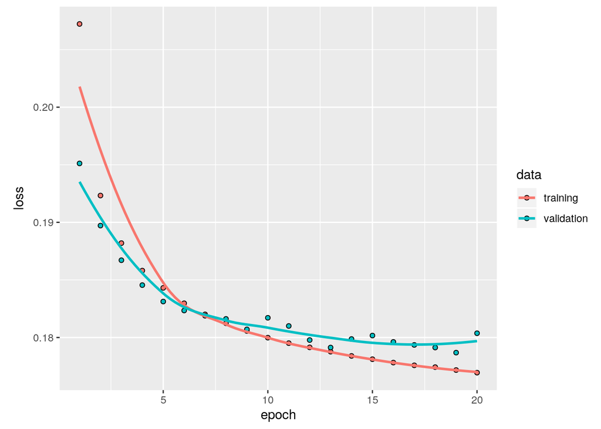

```r
load_model_weights_tf(vae, "def_vae/default_vae")
if (getRversion() < '3.5.0') {
  history_vae <- readRDS("def_vae/history3_5.rds.rds")
} else {
  history_vae <- readRDS("def_vae/history.rds")
}

plot(history_vae)
```

### Image generation

Once we have our trained model, we can use the `decoder` network to turn arbitrary latent space vectors into images.

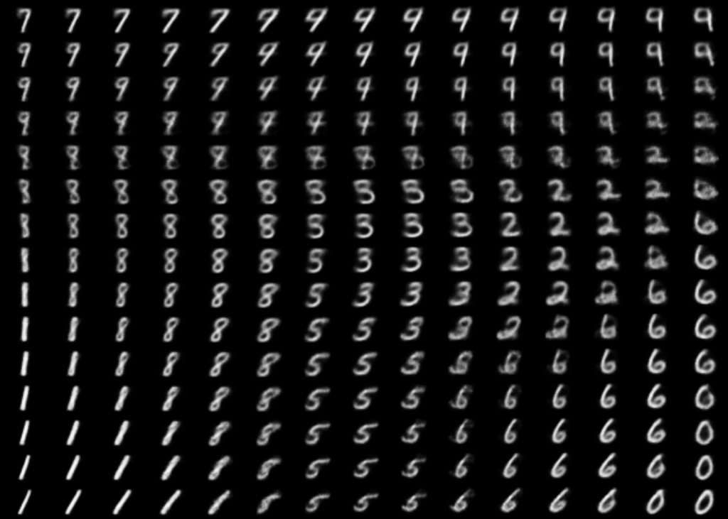

```r
n = 15
digit_size = 28
# n  = Number of rows / columns of digits
# digit_size =  Height / width of digits in pixels

# Transforms linearly spaced coordinates on the unit square through the inverse
# CDF (ppf) of the Gaussian to produce values of the latent variables z,
# because the prior of the latent space is Gaussian
grid_x <- qnorm(seq(0.05, 0.95, length.out = n))
grid_y <- qnorm(seq(0.05, 0.95, length.out = n))

op <- par(mfrow = c(n, n), mar = c(0,0,0,0), bg = "black")
for (i in 1:length(grid_x)) {
  yi <- grid_x[[i]]
  for (j in 1:length(grid_y)) {
    xi <- grid_y[[j]]
    z_sample <- matrix(c(xi, yi), nrow = 1, ncol = 2)
    z_sample <- t(replicate(batch_size, z_sample, simplify = "matrix"))
    x_decoded <- decoder %>% predict(z_sample, batch_size = batch_size)
    digit <- array_reshape(x_decoded[1,,,], dim = c(digit_size, digit_size))
    plot(as.raster(digit))
  }
}
```

The grid of sampled digits shows a completely continuous distribution of the different digit classes, with one digit morphing into another as you follow a path through latent space. Specific directions in this space have a meaning, e.g. there is a direction for “four-ness”, “one-ness”, etc. This is one main difference with traditional autoencoders.

## Exercises

### A. Latent space visualization

Visualize the latent space before and after training. In the same plot, show how the different classes are grouped.

Tip: use the `encoder` model and the `predict` function.

### B. Image generation

Produce a new pannel of numbers, this time using a non-normal distribution.

What changes with the grid of samples shown in the example ?

### C. KL loss

In this section we will see the importance of the KL loss.

Recompile the VAE that we created but by removing the KL loss.

Once you are done, you can load the corresponding VAE’s weights that we already trained and generate a new pannel of numbers from it. What changes with the grid of samples shown in the example ?

```r
    history_vae <- vae %>% fit(
      x = x_train, y = NULL,
      epochs = 10,
      batch_size = batch_size,
      validation_data = list(x_test, NULL)
    )

vae %>% save_model_weights_tf("noKL_vae/noKL_vae")
saveRDS(history_vae, "noKL_vae/history.rds")
saveRDS(history_vae, "noKL_vae/history3_5.rds", version = 2)
```

### D. Dimensionality variation

Look at the models output shape and identify which layers are shrinking the input image (and to what dimensionality) and which layers are extending it (again, with the corresponding dimensionality).